# ml1_hnd241_a_006

```python
import pandas as pd
import missingno as msno
import matplotlib.pyplot as plt
import numpy as np
from scipy.stats import chi2_contingency
from sklearn.impute import SimpleImputer
import warnings
warnings.filterwarnings('ignore')
import pandas as pd
import seaborn as sns
from sklearn.preprocessing import LabelEncoder
from sklearn.tree import DecisionTreeClassifier, DecisionTreeRegressor
from sklearn.ensemble import RandomForestClassifier
from sklearn.neighbors import KNeighborsClassifier
from sklearn.metrics import accuracy_score, classification_report
from sklearn.pipeline import Pipeline
from sklearn.preprocessing import StandardScaler
from sklearn.decomposition import PCA
from sklearn.ensemble import RandomForestClassifier
from sklearn.base import BaseEstimator, TransformerMixin
from sklearn.base import BaseEstimator, TransformerMixin
from sklearn.pipeline import Pipeline
from sklearn.preprocessing import StandardScaler
from sklearn.ensemble import RandomForestClassifier
from sklearn.model_selection import cross_val_score
```

### All required libraries are loaded to carry on the research

```python
df=pd.read_csv('kidney_disease.csv')
df.head(8)
```

|  | id | age | bp | sg | al | su | rbc | pc | pcc | ba | ... | pcv | wc | rc | htn | dm | cad | appet | pe | ane | classification |
| --- | --- | --- | --- | --- | --- | --- | --- | --- | --- | --- | --- | --- | --- | --- | --- | --- | --- | --- | --- | --- | --- |
| 0 | 0 | 48.0 | 80.0 | 1.020 | 1.0 | 0.0 | NaN | normal | notpresent | notpresent | ... | 44 | 7800 | 5.2 | yes | yes | no | good | no | no | ckd |
| 1 | 1 | 7.0 | 50.0 | 1.020 | 4.0 | 0.0 | NaN | normal | notpresent | notpresent | ... | 38 | 6000 | NaN | no | no | no | good | no | no | ckd |
| 2 | 2 | 62.0 | 80.0 | 1.010 | 2.0 | 3.0 | normal | normal | notpresent | notpresent | ... | 31 | 7500 | NaN | no | yes | no | poor | no | yes | ckd |
| 3 | 3 | 48.0 | 70.0 | 1.005 | 4.0 | 0.0 | normal | abnormal | present | notpresent | ... | 32 | 6700 | 3.9 | yes | no | no | poor | yes | yes | ckd |
| 4 | 4 | 51.0 | 80.0 | 1.010 | 2.0 | 0.0 | normal | normal | notpresent | notpresent | ... | 35 | 7300 | 4.6 | no | no | no | good | no | no | ckd |
| 5 | 5 | 60.0 | 90.0 | 1.015 | 3.0 | 0.0 | NaN | NaN | notpresent | notpresent | ... | 39 | 7800 | 4.4 | yes | yes | no | good | yes | no | ckd |
| 6 | 6 | 68.0 | 70.0 | 1.010 | 0.0 | 0.0 | NaN | normal | notpresent | notpresent | ... | 36 | NaN | NaN | no | no | no | good | no | no | ckd |
| 7 | 7 | 24.0 | NaN | 1.015 | 2.0 | 4.0 | normal | abnormal | notpresent | notpresent | ... | 44 | 6900 | 5 | no | yes | no | good | yes | no | ckd |

8 rows × 26 columns

### Data set is been loaded and the first 8 rows are been displayed

```python
print(df.info())
```

```
<class 'pandas.core.frame.DataFrame'>
RangeIndex: 400 entries, 0 to 399
Data columns (total 26 columns):
 #   Column          Non-Null Count  Dtype
---  ------          --------------  -----
 0   id              400 non-null    int64
 1   age             391 non-null    float64
 2   bp              388 non-null    float64
 3   sg              353 non-null    float64
 4   al              354 non-null    float64
 5   su              351 non-null    float64
 6   rbc             248 non-null    object
 7   pc              335 non-null    object
 8   pcc             396 non-null    object
 9   ba              396 non-null    object
```

[output cut: 19 more lines]

### An overview about the dataset before pre processing is given above.This dataset considers of 26 variables and 400 rows.The variables are numerical and catergorical variables.

# Data preprocessing

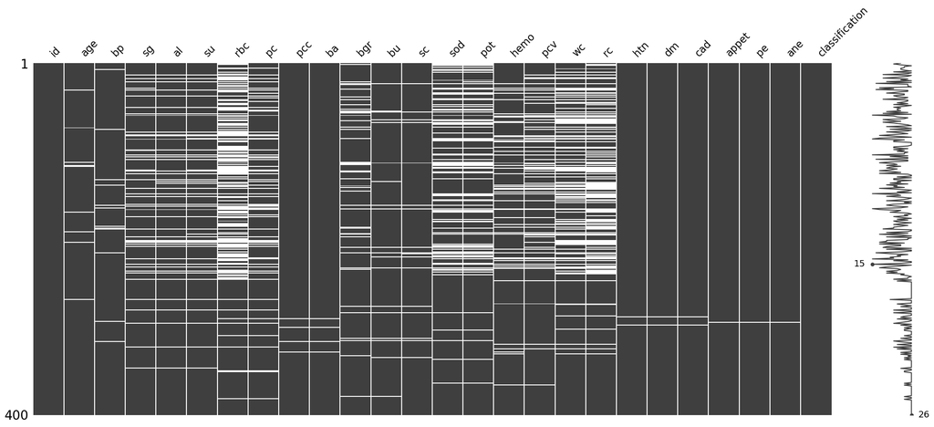

```python
msno.matrix(df)
plt.show()
```

### This is a visualization of the missing values before treating them.

```python
# check missing values
missing_values = df.isnull().sum()
missing_values
```

```
id                  0
age                 9
bp                 12
sg                 47
al                 46
su                 49
rbc               152
pc                 65
pcc                 4
ba                  4
bgr                44
bu                 19
sc                 17
sod                87
pot                88
hemo               52
pcv                70
wc                105
rc                130
htn                 2
dm                  2
cad                 2
appet               1
pe                  1
ane                 1
classification      0
dtype: int64
```

### The above shows the numbr of missing values each variable consists of.As seen above this dataset consists of a lot missing vaues.

```python
# Remove Columns with >20% Missing Data
threshold = len(df) * 0.2
df_cleaned = df.loc[:, df.isnull().sum() <= threshold]
dropped_columns = df.columns.difference(df_cleaned.columns)
print(f"Columns dropped due to >20% missing data: {list(dropped_columns)}")

# Create a binary missing indicator for each column
missing_indicators = df_cleaned.isnull().astype(int)

# Display missing data indicators
print("Missing Data Indicators:\n", missing_indicators.sum())

# Impute Missing Values (Simple Imputation Strategy)
num_cols = df_cleaned.select_dtypes(include=np.number).columns
cat_cols = df_cleaned.select_dtypes(exclude=np.number).columns

# Mean Imputation for Numerical Columns
num_imputer = SimpleImputer(strategy='mean')
df_cleaned[num_cols] = num_imputer.fit_transform(df_cleaned[num_cols])

# Most Frequent Imputation for Categorical Columns
cat_imputer = SimpleImputer(strategy='most_frequent')
df_cleaned[cat_cols] = cat_imputer.fit_transform(df_cleaned[cat_cols])

# Save the Cleaned Data
df_cleaned.to_csv('preprocessed_kidney_disease.csv', index=False)
print("Preprocessed dataset saved successfully.")
```

```
Columns dropped due to >20% missing data: ['pot', 'rbc', 'rc', 'sod', 'wc']
Missing Data Indicators:
 id                 0
age                9
bp                12
sg                47
al                46
su                49
pc                65
pcc                4
ba                 4
bgr               44
bu                19
sc                17
hemo              52
pcv               70
htn                2
dm                 2
cad                2
appet              1
pe                 1
ane                1
classification     0
dtype: int64
Preprocessed dataset saved successfully.
```

### The preprocessing of this data set has been broken down into two parts.First if the attributes have more than 20% of thier columns they were removed.This is done because the more the missing values it reduces the performances and the accuracy level of the model.And having large number of missing values would result in a huge computational load so by removing the missing values the computational load is also reduced.There is no universal that 20% of the data is always removed the percentage of data removal is always a wish of the programmer.Because this step 'pot', 'rbc', 'rc', 'sod', 'wc'were removed from the dataset.

### Eventhough some of the attributes were removed there are some more missing values distributed through out the dataset.For the missing numerical values they will be replaced by the mean values of the respective columns.For the missing values ion the catergorical columns the most occured value was replaced for thier respective column.

### Missing values are mainly handled to improve the performance and the accuracy of the models.

## Eventhough the paper says that the researchers have not taken the removed data into consideration some images after preprocessing the data clearly depict that after the process there had been all 26 variables in the dataset.But i have carried out my research clearly according to the given steps so i have done it without taking the removed data into consideration.

```python
# Assuming DropHighMissingColumns is correctly defined
pipeline = Pipeline([
    ('drop_missing', DropHighMissingColumns(threshold=0.2)),  # Custom transformer
    ('impute', SimpleImputer(strategy='mean')),  # Impute missing values
    ('scaler', StandardScaler()),  # Optional: Scale features
    ('classifier', RandomForestClassifier())
])
pipeline
```

```
Pipeline(steps=[('drop_missing', DropHighMissingColumns()),
                ('impute', SimpleImputer()), ('scaler', StandardScaler()),
                ('classifier', RandomForestClassifier())])
```

```python
summary = df_cleaned.describe()
summary
```

|  | id | age | bp | sg | al | su | bgr | bu | sc | hemo |
| --- | --- | --- | --- | --- | --- | --- | --- | --- | --- | --- |
| count | 400.000000 | 400.000000 | 400.000000 | 400.000000 | 400.000000 | 400.000000 | 400.000000 | 400.000000 | 400.000000 | 400.000000 |
| mean | 199.500000 | 51.483376 | 76.469072 | 1.017408 | 1.016949 | 0.450142 | 148.036517 | 57.425722 | 3.072454 | 12.526437 |
| std | 115.614301 | 16.974966 | 13.476298 | 0.005369 | 1.272318 | 1.029487 | 74.782634 | 49.285887 | 5.617490 | 2.716171 |
| min | 0.000000 | 2.000000 | 50.000000 | 1.005000 | 0.000000 | 0.000000 | 22.000000 | 1.500000 | 0.400000 | 3.100000 |
| 25% | 99.750000 | 42.000000 | 70.000000 | 1.015000 | 0.000000 | 0.000000 | 101.000000 | 27.000000 | 0.900000 | 10.875000 |
| 50% | 199.500000 | 54.000000 | 78.234536 | 1.017408 | 1.000000 | 0.000000 | 126.000000 | 44.000000 | 1.400000 | 12.526437 |
| 75% | 299.250000 | 64.000000 | 80.000000 | 1.020000 | 2.000000 | 0.450142 | 150.000000 | 61.750000 | 3.072454 | 14.625000 |
| max | 399.000000 | 90.000000 | 180.000000 | 1.025000 | 5.000000 | 5.000000 | 490.000000 | 391.000000 | 76.000000 | 17.800000 |

### Here is a description of the data set after treating missing values

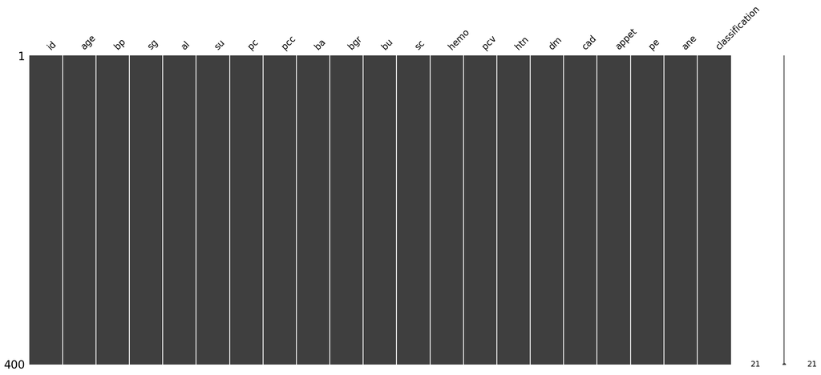

```
Chi-Square Statistic: nan
P-Value: nan
Degrees of Freedom: 7980
```

```python
# Visualize Missing Data Patterns
msno.matrix(df_cleaned)
plt.show()

# Create a Missing Data Indicator Matrix
missing_data = df_cleaned.isnull().astype(int)

# Compute Chi-Square Test for MCAR Approximation
chi2_stat, p_val, dof, expected = chi2_contingency(missing_data.T)

print(f"Chi-Square Statistic: {chi2_stat}")
print(f"P-Value: {p_val}")
print(f"Degrees of Freedom: {dof}")
```

### The degrees of freedom in this dataset has gained a high value (7980).The number of independent choices that we have in a dataset when we are calculating statistic values are known as degree of freedom. The degree of freedom is calculated by = (number of rows -1) x (number of columns -1).The higher the degree of freedom values increase the more the reliability decreases.

### The main objective in using a chi squared test here was to see the relationship between variables ,find the missing value patterns and to find the statistical methods that can be used to fill missing values.But as I all the missing values had already been treated in the first phase of pre processing.

### Eventhough the paper has mentioned that they have done the chi squared test it cannot be done as the encoding has been done in the latter part of the preprocessing phase.This is also another issue that was identified when recreating this paper as the preprocessing part has a major effect on the output.

```python
# Create a Missing Data Indicator Matrix
missing_data = df_cleaned.isnull().astype(int)

# Compute Chi-Square Test for MCAR Approximation
chi2_stat, p_val, dof, expected = chi2_contingency(missing_data.T)

# Output the results
print(f"Chi-Square Statistic: {chi2_stat}")
print(f"P-Value: {p_val}")
print(f"Degrees of Freedom: {dof}")

# Interpretation
alpha = 0.05
if p_val > alpha:
    print("The data is likely MCAR (Missing Completely at Random).")
else:
    print("The data is not MCAR.")
```

```
Chi-Square Statistic: nan
P-Value: nan
Degrees of Freedom: 7980
The data is not MCAR.
```

```python
missing_values = df_cleaned.isnull().sum()
missing_values
```

```
id                0
age               0
bp                0
sg                0
al                0
su                0
pc                0
pcc               0
ba                0
bgr               0
bu                0
sc                0
hemo              0
pcv               0
htn               0
dm                0
cad               0
appet             0
pe                0
ane               0
classification    0
dtype: int64
```

### The above shows that there arent any missing values in the dataset when going forward.

```python
print(df_cleaned.info())
```

```
<class 'pandas.core.frame.DataFrame'>
RangeIndex: 400 entries, 0 to 399
Data columns (total 21 columns):
 #   Column          Non-Null Count  Dtype
---  ------          --------------  -----
 0   id              400 non-null    float64
 1   age             400 non-null    float64
 2   bp              400 non-null    float64
 3   sg              400 non-null    float64
 4   al              400 non-null    float64
 5   su              400 non-null    float64
 6   pc              400 non-null    object
 7   pcc             400 non-null    object
 8   ba              400 non-null    object
 9   bgr             400 non-null    float64
 10  bu              400 non-null    float64
 11  sc              400 non-null    float64
 12  hemo            400 non-null    float64
 13  pcv             400 non-null    object
 14  htn             400 non-null    object
 15  dm              400 non-null    object
 16  cad             400 non-null    object
 17  appet           400 non-null    object
 18  pe              400 non-null    object
 19  ane             400 non-null    object
 20  classification  400 non-null    object
dtypes: float64(10), object(11)
memory usage: 65.8+ KB
None
```

```python
# label encoding
var_enc = ['htn','dm','cad','appet','pe','ane','pc','pcc','pcv','ba','classification']

# Dictionary to store mappings for each column
mappings = {}

for col in var_enc:
    le = LabelEncoder()  # Create a new LabelEncoder instance for each column
    df_cleaned[col] = le.fit_transform(df_cleaned[col])
    # Store the mapping in the dictionary
    mappings[col] = dict(zip(le.classes_, le.transform(le.classes_)))

# Print the mappings for each column
for col, mapping in mappings.items():
    print(f"Mapping for {col}:")
    for original, encoded in mapping.items():
        print(f"{original}: {encoded}")
    print("\n")
```

```
Mapping for htn:
no: 0
yes: 1


Mapping for dm:
	no: 0
	yes: 1
 yes: 2
no: 3
yes: 4


Mapping for cad:
	no: 0
no: 1
yes: 2


Mapping for appet:
good: 0
poor: 1


Mapping for pe:
no: 0
yes: 1


Mapping for ane:
no: 0
yes: 1


Mapping for pc:
abnormal: 0
normal: 1


Mapping for pcc:
```

[output cut: 45 more lines]

```
52: 40
53: 41
54: 42
9: 43


Mapping for ba:
notpresent: 0
present: 1


Mapping for classification:
ckd: 0
ckd	: 1
notckd: 2
```

### Most machine learning models always need numerical inputs to run thier models.In such events encoding comes in handy, where all the catergorical value can be calculated into numerical value easily.When label encoding it gives each an every catergorical value a unique interger value.Such as 1 and 0.

### Here these variables had been encoded 'htn','dm','cad','appet','pe','ane','pc','pcc','pcv','ba','classification'.And the mappings had also been provided.

### Mostly label encoding is easy to use when the values are ordinal.The main objective of label encoding is making the data machine compatible.Whilst thier are some limitations when using label encoding such as the it intends to build an unitended ordinal relationship between values.

```python
preprocessing_pipeline = ['htn','dm','cad','appet','pe','ane','pc','pcc','pcv','ba','classification']
preprocessing_pipeline = Pipeline(steps=[
    ('LabelEncode', LabelEncoder())
])

preprocessing_pipeline
```

```
Pipeline(steps=[('LabelEncode', LabelEncoder())])
```

```python
print(df_cleaned.info())
```

```
<class 'pandas.core.frame.DataFrame'>
RangeIndex: 400 entries, 0 to 399
Data columns (total 21 columns):
 #   Column          Non-Null Count  Dtype
---  ------          --------------  -----
 0   id              400 non-null    float64
 1   age             400 non-null    float64
 2   bp              400 non-null    float64
 3   sg              400 non-null    float64
 4   al              400 non-null    float64
 5   su              400 non-null    float64
 6   pc              400 non-null    int32
 7   pcc             400 non-null    int32
 8   ba              400 non-null    int32
 9   bgr             400 non-null    float64
 10  bu              400 non-null    float64
 11  sc              400 non-null    float64
 12  hemo            400 non-null    float64
 13  pcv             400 non-null    int32
 14  htn             400 non-null    int32
 15  dm              400 non-null    int32
 16  cad             400 non-null    int32
 17  appet           400 non-null    int32
 18  pe              400 non-null    int32
 19  ane             400 non-null    int32
 20  classification  400 non-null    int32
dtypes: float64(10), int32(11)
memory usage: 48.6 KB
None
```

```python
df_cleaned
```

|  | id | age | bp | sg | al | su | pc | pcc | ba | bgr | ... | sc | hemo | pcv | htn | dm | cad | appet | pe | ane | classification |
| --- | --- | --- | --- | --- | --- | --- | --- | --- | --- | --- | --- | --- | --- | --- | --- | --- | --- | --- | --- | --- | --- |
| 0 | 0.0 | 48.0 | 80.0 | 1.020 | 1.0 | 0.0 | 1 | 0 | 0 | 121.000000 | ... | 1.2 | 15.4 | 32 | 1 | 4 | 1 | 0 | 0 | 0 | 0 |
| 1 | 1.0 | 7.0 | 50.0 | 1.020 | 4.0 | 0.0 | 1 | 0 | 0 | 148.036517 | ... | 0.8 | 11.3 | 26 | 0 | 3 | 1 | 0 | 0 | 0 | 0 |
| 2 | 2.0 | 62.0 | 80.0 | 1.010 | 2.0 | 3.0 | 1 | 0 | 0 | 423.000000 | ... | 1.8 | 9.6 | 19 | 0 | 4 | 1 | 1 | 0 | 1 | 0 |
| 3 | 3.0 | 48.0 | 70.0 | 1.005 | 4.0 | 0.0 | 0 | 1 | 0 | 117.000000 | ... | 3.8 | 11.2 | 20 | 1 | 3 | 1 | 1 | 1 | 1 | 0 |
| 4 | 4.0 | 51.0 | 80.0 | 1.010 | 2.0 | 0.0 | 1 | 0 | 0 | 106.000000 | ... | 1.4 | 11.6 | 23 | 0 | 3 | 1 | 0 | 0 | 0 | 0 |
| ... | ... | ... | ... | ... | ... | ... | ... | ... | ... | ... | ... | ... | ... | ... | ... | ... | ... | ... | ... | ... | ... |
| 395 | 395.0 | 55.0 | 80.0 | 1.020 | 0.0 | 0.0 | 1 | 0 | 0 | 140.000000 | ... | 0.5 | 15.7 | 35 | 0 | 3 | 1 | 0 | 0 | 0 | 2 |
| 396 | 396.0 | 42.0 | 70.0 | 1.025 | 0.0 | 0.0 | 1 | 0 | 0 | 75.000000 | ... | 1.2 | 16.5 | 42 | 0 | 3 | 1 | 0 | 0 | 0 | 2 |
| 397 | 397.0 | 12.0 | 80.0 | 1.020 | 0.0 | 0.0 | 1 | 0 | 0 | 100.000000 | ... | 0.6 | 15.8 | 37 | 0 | 3 | 1 | 0 | 0 | 0 | 2 |
| 398 | 398.0 | 17.0 | 60.0 | 1.025 | 0.0 | 0.0 | 1 | 0 | 0 | 114.000000 | ... | 1.0 | 14.2 | 39 | 0 | 3 | 1 | 0 | 0 | 0 | 2 |
| 399 | 399.0 | 58.0 | 80.0 | 1.025 | 0.0 | 0.0 | 1 | 0 | 0 | 131.000000 | ... | 1.1 | 15.8 | 41 | 0 | 3 | 1 | 0 | 0 | 0 | 2 |

400 rows × 21 columns

```python
print(df_cleaned['bu'].head())
```

```
0    36.0
1    18.0
2    53.0
3    56.0
4    26.0
Name: bu, dtype: float64
```

```python
df_cleaned['bgr'] = df_cleaned['bgr'].astype(int)
```

```python
df_cleaned.head()
```

|  | id | age | bp | sg | al | su | pc | pcc | ba | bgr | ... | sc | hemo | pcv | htn | dm | cad | appet | pe | ane | classification |
| --- | --- | --- | --- | --- | --- | --- | --- | --- | --- | --- | --- | --- | --- | --- | --- | --- | --- | --- | --- | --- | --- |
| 0 | 0.0 | 48.0 | 80.0 | 1.020 | 1.0 | 0.0 | 1 | 0 | 0 | 121 | ... | 1.2 | 15.4 | 32 | 1 | 4 | 1 | 0 | 0 | 0 | 0 |
| 1 | 1.0 | 7.0 | 50.0 | 1.020 | 4.0 | 0.0 | 1 | 0 | 0 | 148 | ... | 0.8 | 11.3 | 26 | 0 | 3 | 1 | 0 | 0 | 0 | 0 |
| 2 | 2.0 | 62.0 | 80.0 | 1.010 | 2.0 | 3.0 | 1 | 0 | 0 | 423 | ... | 1.8 | 9.6 | 19 | 0 | 4 | 1 | 1 | 0 | 1 | 0 |
| 3 | 3.0 | 48.0 | 70.0 | 1.005 | 4.0 | 0.0 | 0 | 1 | 0 | 117 | ... | 3.8 | 11.2 | 20 | 1 | 3 | 1 | 1 | 1 | 1 | 0 |
| 4 | 4.0 | 51.0 | 80.0 | 1.010 | 2.0 | 0.0 | 1 | 0 | 0 | 106 | ... | 1.4 | 11.6 | 23 | 0 | 3 | 1 | 0 | 0 | 0 | 0 |

5 rows × 21 columns

```python
df_cleaned.shape
df_cleaned.info()
```

```
<class 'pandas.core.frame.DataFrame'>
RangeIndex: 400 entries, 0 to 399
Data columns (total 21 columns):
 #   Column          Non-Null Count  Dtype
---  ------          --------------  -----
 0   id              400 non-null    float64
 1   age             400 non-null    float64
 2   bp              400 non-null    float64
 3   sg              400 non-null    float64
 4   al              400 non-null    float64
 5   su              400 non-null    float64
 6   pc              400 non-null    int32
 7   pcc             400 non-null    int32
 8   ba              400 non-null    int32
 9   bgr             400 non-null    int32
 10  bu              400 non-null    float64
 11  sc              400 non-null    float64
 12  hemo            400 non-null    float64
 13  pcv             400 non-null    int32
 14  htn             400 non-null    int32
 15  dm              400 non-null    int32
 16  cad             400 non-null    int32
 17  appet           400 non-null    int32
 18  pe              400 non-null    int32
 19  ane             400 non-null    int32
 20  classification  400 non-null    int32
dtypes: float64(9), int32(12)
memory usage: 47.0 KB
```

### Like mentioned earlier there were several unclear places in this research paper while recreating it

# Feature Selection

```python
pip install aco-python
```

```
ERROR: Could not find a version that satisfies the requirement aco-python (from versions: none)
ERROR: No matching distribution found for aco-python
```

```python
from sklearn.preprocessing import LabelEncoder

# Create a copy of the dataframe to work with
df_encoded = df_cleaned.copy()

# Identify categorical columns (assuming they are of dtype 'object')
categorical_cols = df_encoded.select_dtypes(include=['object']).columns

# Apply Label Encoding to categorical columns
label_encoders = {}
for col in categorical_cols:
    le = LabelEncoder()
    df_encoded[col] = le.fit_transform(df_encoded[col])
    label_encoders[col] = le

# Now, df_encoded is fully numeric
```

### Feature selection is the process which helps to identify the main variable/variables which contribute to the machine learning model.In this research paper Ant Colony Optimization (ACO) has been used.

### Ant colony optimozation is an optimization algorithm which is built based on the behaviour of ants.Ants choose the shortest path between thier food source and colony by laying pheromones(a chemical substance layed by ants), when pheromones are layed it tends to attract other ants which results in everyone using the same paath.Over time when the same path is used for a particular time period the paths automatically convert into good algorithms where ants find solutions for thier hardships.

### Similar applications of ACO is Feature selection,Network routing,Traveling sales problem and vehicle routing problem

### ACO is a very flexible optimization method whilst it can also be a very computationally expensive algorithm

### Here for reassurance again a label encoding code has been used

```python
import pandas as pd
import numpy as np
from sklearn.model_selection import train_test_split, cross_val_score
from sklearn.ensemble import RandomForestClassifier
from sklearn.tree import DecisionTreeClassifier
from sklearn.neighbors import KNeighborsClassifier
from sklearn.metrics import classification_report, accuracy_score

# For the ACO implementation
class AntColonyOptimizer:
    def __init__(self, n_ants, n_iterations, decay, alpha=1, beta=1):
        self.n_ants = n_ants
        self.n_iterations = n_iterations
        self.decay = decay
        self.alpha = alpha
        self.beta = beta

    def fit(self, X, y):
        n_features = X.shape[1]
        pheromone = np.ones(n_features)
        best_score = -np.inf
        best_solution = None

        for i in range(self.n_iterations):
            solutions = self.generate_solutions(pheromone, n_features)
            scores = self.evaluate_solutions(solutions, X, y)
            best_iteration_score = max(scores)
            best_iteration_solution = solutions[np.argmax(scores)]

            if best_iteration_score > best_score:
                best_score = best_iteration_score
                best_solution = best_iteration_solution

            pheromone = self.update_pheromone(pheromone, solutions, scores)

        return best_solution, best_score

    def generate_solutions(self, pheromone, n_features):
        solutions = []
        for _ in range(self.n_ants):
            solution = []
            for i in range(n_features):
                if np.random.rand() < pheromone[i]:
                    solution.append(i)
            solutions.append(solution)
        return solutions

    def evaluate_solutions(self, solutions, X, y):
        scores = []
        for solution in solutions:
            if len(solution) == 0:
                scores.append(0)
                continue
            X_subset = X[:, solution]
            score = cross_val_score(RandomForestClassifier(), X_subset, y, cv=3).mean()
            scores.append(score)
        return scores

    def update_pheromone(self, pheromone, solutions, scores):
        for i in range(len(pheromone)):
            pheromone[i] *= self.decay
            for j in range(len(solutions)):
                if i in solutions[j]:
                    pheromone[i] += scores[j]
        return pheromone
```

### The main objective of ACO is to increase the accuracy of the model.Overtime the path becomes more optimal.Here is a break ddown of the above code.

### 1.Initialization

### Initilizes the process by giving pheromone levels for each data

### 2.Iteration process

### After deploying a popualtion of ants every single ant has a duty to construct a feature subset based on the pheromone level

### 3.Solution generation

### The more the pheromone level the more it has a chance to be included in the subset.

### 4.Solution Evaluation

### Once a subset of features are selected a random forest classifier is used to evaluate the model.After the evaluation cross validation is used to check the performance of the model then its accuracy is noted as the fitness of the model.

### 5.Pheromone update

### After the evaluation the pheromones are again updated

### 6.convergence

### Next the final solution is been chosed.The highest recorded subset performance is selected.

```python
# Define feature matrix X and target vector y
X = df_cleaned.drop(columns=["classification"]).values
y = df_cleaned["classification"].values
```

### The main variable is identified

```python
# Instantiate and fit ACO
aco = AntColonyOptimizer(n_ants=10, n_iterations=20, decay=0.95)
best_solution, best_score = aco.fit(X, y)

# Select the best features
X_selected = X[:, best_solution]

print("Best subset of features:", best_solution)
print("Best cross-validated score:", best_score)
```

```
Best subset of features: [0, 1, 2, 3, 4, 5, 6, 7, 8, 9, 10, 11, 12, 13, 14, 15, 16, 17, 18, 19]
Best cross-validated score: 0.987524782104515
```

### Here 10 ants are deployed,20 iterations and the decay rate is givenn as 0.95.

### Fit is used to find the best optimal subset of features with best solution whilst the best score gives us the cross validatd score

### Next using the observed best features a new feature matrix is created.

### Finally the best selected subset features and the best cross validated score is printed

# Classifiers

### Precision = This shows the number of predicted positives which were really positive

### Recall = The amount of actually positives which were correctly figured.

### F1 score = Gets precision and recall to a single metric(Balances)

### Macro avg = Calculates all unweighted mean which is distributed through precision,recall and f1 score across all classes.Here all the classes are been treated equally

### Weighted average = Makes sure that all the classes that have contributed to the overall average are proportional to its size in the dataset.

### Random Forest

```python
#splitting the data : 67% train and 33% test
X_train_, X_test_, y_train_, y_test_ = train_test_split(X,y,test_size = 0.33, random_state = 42)
X_train_.shape
#state is random no genarator. we can use any value to state to inizialize the random no. generator.
```

```
(268, 20)
```

```python
# Model initialization
model_rf = RandomForestClassifier(n_estimators=100, random_state=42, class_weight='balanced')
```

```python
# Fit the data (train the model)
model_rf.fit(X_train_, y_train_)
```

```
RandomForestClassifier(class_weight='balanced', random_state=42)
```

```python
random_forest_pipeline = Pipeline(steps=[
    ('pipeline', pipeline),
    ('classifier', RandomForestClassifier())
])
random_forest_pipeline
```

```
Pipeline(steps=[('pipeline',
                 Pipeline(steps=[('drop_missing', DropHighMissingColumns()),
                                 ('impute', SimpleImputer()),
                                 ('scaler', StandardScaler()),
                                 ('classifier', RandomForestClassifier())])),
                ('classifier', RandomForestClassifier())])
```

```python
# Model prediction on new data (X_test_)
y_pred_rf = model_rf.predict(X_test_)
```

```python
from sklearn.metrics import precision_score, recall_score, f1_score, accuracy_score
# Model Metrics and Evaluation
print("Classification accuracy:", accuracy_score(y_test_, y_pred_rf))
print("Precision:", precision_score(y_test_, y_pred_rf, average='weighted', zero_division=0))
print("Recall:", recall_score(y_test_, y_pred_rf, average='weighted', zero_division=0))
print("F1 score:", f1_score(y_test_, y_pred_rf, average='weighted', zero_division=0))
```

```
Classification accuracy: 1.0
Precision: 1.0
Recall: 1.0
F1 score: 1.0
```

```python
# Print classification report
print("\nClassification Report:")
print(classification_report(y_test_, y_pred_rf, zero_division=0))
```

```
Classification Report:
              precision    recall  f1-score   support

           0       1.00      1.00      1.00        84
           2       1.00      1.00      1.00        48

    accuracy                           1.00       132
   macro avg       1.00      1.00      1.00       132
weighted avg       1.00      1.00      1.00       132
```

### Random forest classification is used to create various models and improve accuracy and stability of the overall model.

### This random forest classification report shows us that the model fits exceptionally well giving us an accuracy of 100%.It shows us that this model doesnt have an error but however when it comes to the practical world this might have slight changes.

### Mostly the accuracy the accuracy becomes 100%when the model becomes overfit.There might be something wrong when the data had been split.

### Decision tree

```python
#splitting the data : 67% train and 33% test
X_train_, X_test_, y_train_, y_test_ = train_test_split(X,y,test_size = 0.33, random_state = 42)
X_train_.shape
#state is random no genarator. we can use any value to state to inizialize the random no. generator.
```

```
(268, 20)
```

### Here "X" is the fetures of the dataset and "Y" is the targeted variable.Then the data is been divided into training and training sets.33% of the data will be used to test and 67% wuld be used to train the data

```python
from sklearn.preprocessing import Normalizer
# Normalize the data
X_train_ = Normalizer().fit_transform(X_train_)
X_test_ = Normalizer().fit_transform(X_test_)
```

### Normalize is another way to make the data ready to be fed to make a model.It converts data into any range making the the data readable for the computer

```python
# Standardize the data
scaler = StandardScaler()
X_train_ = scaler.fit_transform(X_train_)
X_test_ = scaler.transform(X_test_)
```

### The data is transformed into 0 1 associated with thier mean and standard deviation values

```python
# Initialize and train the decision tree regressor
model = DecisionTreeRegressor(random_state=42)
model.fit(X_train_, y_train_)
```

```
DecisionTreeRegressor(random_state=42)
```

```python
Decision_Tree_pipeline = Pipeline(steps=[
    ('pipeline', pipeline),
    ('classifier', DecisionTreeRegressor())
])
Decision_Tree_pipeline
```

```
Pipeline(steps=[('pipeline',
                 Pipeline(steps=[('drop_missing', DropHighMissingColumns()),
                                 ('impute', SimpleImputer()),
                                 ('scaler', StandardScaler()),
                                 ('classifier', RandomForestClassifier())])),
                ('classifier', DecisionTreeRegressor())])
```

```python
# Make predictions on the test data
y_pred = model.predict(X_test_)


print(y_pred.shape)
```

```
(132,)
```

```python
from sklearn.tree import DecisionTreeClassifier

# Initialize and train the decision tree regressor
model = DecisionTreeClassifier(max_depth=5, random_state=42)
model.fit(X_train_, y_train_)

y_pred = model.predict(X_test_)
print(y_pred)
```

```
[0 2 0 0 0 0 2 0 2 0 0 2 0 0 0 0 2 2 0 2 0 0 2 2 0 2 0 0 2 0 2 0 2 0 0 0 0
 2 0 0 2 0 0 0 0 2 0 0 0 0 0 2 2 1 2 0 0 0 0 0 0 2 2 0 0 0 2 2 2 0 2 0 0 0
 2 0 0 2 0 2 0 0 0 1 2 0 0 2 0 0 0 2 0 0 0 2 2 2 2 0 0 0 0 0 0 0 0 0 2 2 0
 2 2 2 2 0 0 2 2 2 0 0 0 2 0 0 2 2 0 0 2 0]
```

```python
# Calculate metrics
accuracy = accuracy_score(y_test_, y_pred)
precision = precision_score(y_test_, y_pred, average='weighted')
recall = recall_score(y_test_, y_pred, average='weighted')
f1 = f1_score(y_test_, y_pred, average='weighted')


# Output the results
print(f'Accuracy: {accuracy:.2f}')
print(f'Precision: {precision:.2f}')
print(f'Recall: {recall:.2f}')
print(f'F1 Score: {f1:.2f}')
```

```
Accuracy: 0.98
Precision: 0.99
Recall: 0.98
F1 Score: 0.98
```

```python
print("\nClassification Report:")
print(classification_report(y_test, y_pred, zero_division=0))
```

[output not shown]

### The decision tree accuracy in the research paper is 95%.However after recreating the research paper my decision tree model has aquired a higher accuracy.This can be because of the issues that I had to encounter when pre processing the data.

### KNN

```python
# Initialize and train the KNeighborsClassifier
from sklearn.neighbors import KNeighborsClassifier
model = KNeighborsClassifier(n_neighbors=11)
model.fit(X_train, y_train)
```

```
KNeighborsClassifier(n_neighbors=11)
```

```python
K_Neighbors_pipeline = Pipeline(steps=[
    ('pipeline', pipeline),
    ('classifier', KNeighborsClassifier())
])
K_Neighbors_pipeline
```

```
Pipeline(steps=[('pipeline',
                 Pipeline(steps=[('drop_missing', DropHighMissingColumns()),
                                 ('impute', SimpleImputer()),
                                 ('scaler', StandardScaler()),
                                 ('classifier', RandomForestClassifier())])),
                ('classifier', KNeighborsClassifier())])
```

```python
print("\nClassification Report:")
print(classification_report(y_test, predicted_knn, zero_division=0))
```

[output not shown]

### K Nearest Neighbour is a non-parametric model that classifies data points based on their proximity to other labeled data points. What KNN does is it predicts data for a new data point based on the data which already exist in the dataset.

```python
pipelines = [
    ('drop_missing', DropHighMissingColumns(threshold=0.2)),
    ('impute', ImputeMissingValues()),
    ('scaler', StandardScaler()),
    ('classifier', RandomForestClassifier()),
    ('LabelEncode', LabelEncoder()),
    ('RandomForest', random_forest_pipeline),
    ('DecisionTreeRegressor', Decision_Tree_pipeline),
    ('KNeighborsClassifier', K_Neighbors_pipeline),
]
print(pipelines)
```

[output not shown]